# Complete Agronomic Workflow: Split-Plot Nitrogen Response

mixedFlowR tutorial series

# 1 Purpose

This capstone vignette integrates the major concepts of the tutorial series in one coherent agronomic analysis. The example is a randomized complete-block split-plot trial with variety in whole plots, nitrogen dose in subplots, and yield as the response.

The purpose is not to use every advanced model. The purpose is to show **when** each extension becomes relevant and when the simpler analysis should be retained.

# 2 1. Learning objectives

You will learn to execute a complete workflow:

1. define the scientific question;
2. audit the randomization and experimental units;
3. explore raw data;
4. use legacy ANOVA as a design check;
5. fit the design-correct LMM;
6. diagnose the fit;
7. interpret qualitative and quantitative effects;
8. evaluate uncertainty;
9. conduct robust and bootstrap sensitivity analyses;
10. produce publication-ready figures and tables;
11. generate a reproducibility record;
12. decide whether advanced GAMLSS/Bayesian/spatial extensions are justified.

# 3 2. Scientific question

Assume the study asks:

> Do varieties differ in grain yield, how does yield respond to nitrogen dose, and does the nitrogen response depend on variety when the split-plot randomization is represented correctly?

Secondary questions are:

- Are conclusions sensitive to influential observations?
- Are uncertainty intervals stable under bootstrap resampling?
- Is there evidence that a more complex distributional or covariance model is needed?

# 4 3. Load data and record capabilities

```r
library(mixedFlowR)
d <- mixed_data("splitplot")
head(d)
```

```
#>   block variety nitrogen    yield
#> 1    B1      V1        0 53.92579
#> 2    B1      V1       50 62.24195
#> 3    B1      V1      100 69.33041
#> 4    B1      V1      150 71.76092
#> 5    B1      V2        0 59.14012
#> 6    B1      V2       50 63.76755
```

```r
mixed_capabilities()
```

```
#>         package installed version
#> 1          lme4      TRUE   2.0.6
#> 2          nlme      TRUE 3.1.170
#> 3       glmmTMB      TRUE  1.1.14
#> 4     robustlmm      TRUE 3.5.0.2
#> 5    confintROB      TRUE   1.1.1
#> 6  clubSandwich      TRUE   0.7.0
#> 7      lmerTest      TRUE   3.2.1
#> 8      pbkrtest      TRUE   0.5.5
#> 9       emmeans      TRUE   2.0.4
#> 10       gamlss      TRUE   5.5.0
#> 11  gamlss.dist      TRUE   6.1.1
#> 12         brms      TRUE  2.23.0
#> 13    posterior      TRUE   1.7.0
#> 14          loo      TRUE  2.10.1
#> 15       DHARMa      TRUE   0.5.0
#> 16  performance      TRUE  0.17.1
#> 17 influence.ME      TRUE  0.9.10
#> 18        SpATS      TRUE  1.0.20
#> 19       sommer      TRUE   4.4.6
```

# 5 4. Define the estimands before fitting

**Variety:** qualitative whole-plot treatment.  
**Nitrogen:** quantitative subplot treatment.  
**Variety × nitrogen:** modification of dose response by variety.  
**Block and block-by-variety:** randomization-induced grouping components.

This declaration prevents the analysis from drifting into arbitrary pairwise tests or automatic model selection.

# 6 5. Audit the design

```r
audit <- mixed_design_audit(
  d,
  response = "yield",
  block = "block",
  whole = "variety",
  sub = "nitrogen"
)
audit
```

```
#> $n
#> [1] 72
#>
#> $roles
#>   response      block      whole        sub
#>    "yield"    "block"  "variety" "nitrogen"
#>
#> $balance
#>    block variety nitrogen n
#> 1     B1      V1        0 1
#> 2     B2      V1        0 1
#> 3     B3      V1        0 1
#> 4     B4      V1        0 1
#> 5     B5      V1        0 1
#> 6     B6      V1        0 1
```

[output cut: 169 more lines]

```r
mixed_hierarchy(d, block = "block", whole = "variety", sub = "nitrogen")
```

```
#> $roles
#>      block      whole        sub
#>    "block"  "variety" "nitrogen"
#>
#> $edges
#>    parent    child              relation
#> 1   block  variety declared nested/order
#> 2 variety nitrogen declared nested/order
```

```r
mixed_balance(d, c("block", "variety", "nitrogen"))
```

```
#>    block variety nitrogen n
#> 1     B1      V1        0 1
#> 2     B2      V1        0 1
#> 3     B3      V1        0 1
#> 4     B4      V1        0 1
#> 5     B5      V1        0 1
#> 6     B6      V1        0 1
#> 7     B1      V2        0 1
#> 8     B2      V2        0 1
#> 9     B3      V2        0 1
#> 10    B4      V2        0 1
#> 11    B5      V2        0 1
#> 12    B6      V2        0 1
#> 13    B1      V3        0 1
#> 14    B2      V3        0 1
```

[output cut: 58 more lines]

# 7 6. Explicitly identify whole plots

```r
d$whole_plot <- interaction(d$block, d$variety, drop = TRUE)

mixed_pseudorep(
  d,
  response = "yield",
  cluster = "whole_plot",
  treatment = "variety"
)
```

```
#> $cluster_declared
#> [1] TRUE
#>
#> $counts
#>    cluster treatment n
#> 1    B1.V1        V1 4
#> 2    B2.V1        V1 4
#> 3    B3.V1        V1 4
#> 4    B4.V1        V1 4
#> 5    B5.V1        V1 4
#> 6    B6.V1        V1 4
#> 25   B1.V2        V2 4
#> 26   B2.V2        V2 4
#> 27   B3.V2        V2 4
#> 28   B4.V2        V2 4
#> 29   B5.V2        V2 4
#> 30   B6.V2        V2 4
#> 49   B1.V3        V3 4
#> 50   B2.V3        V3 4
#> 51   B3.V3        V3 4
#> 52   B4.V3        V3 4
#> 53   B5.V3        V3 4
#> 54   B6.V3        V3 4
#>
#> $repeated_within_cluster
#> [1] TRUE
#>
#> $note
#> [1] "Repeated observations within a cluster require an analysis that preserves that dependence; repetition alone does not prove pseudoreplication."
```

The variety treatment is replicated at the whole-plot level, not at the subplot-observation level.

# 8 7. Raw-data exploration

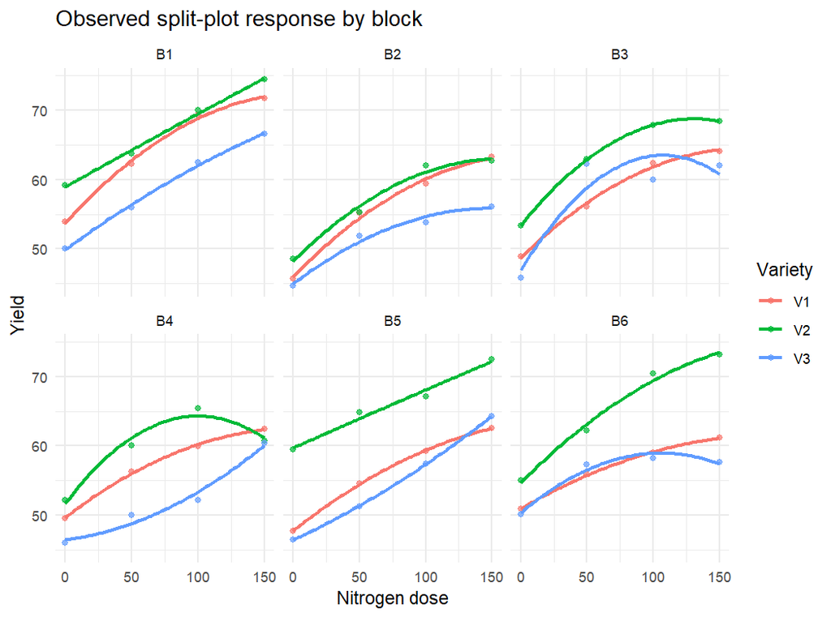

```r
if (requireNamespace("ggplot2", quietly = TRUE)) {
  ggplot2::ggplot(
    d,
    ggplot2::aes(nitrogen, yield, colour = variety)
  ) +
    ggplot2::geom_point(alpha = 0.7) +
    ggplot2::geom_smooth(method = "lm", formula = y ~ poly(x, 2), se = FALSE) +
    ggplot2::facet_wrap(~ block) +
    ggplot2::labs(
      x = "Nitrogen dose",
      y = "Yield",
      colour = "Variety",
      title = "Observed split-plot response by block"
    ) +
    ggplot2::theme_minimal(base_size = 11)
}
```

Questions to ask before modeling:

- Is response plausibly smooth with dose?
- Does one block behave differently?
- Are there isolated extreme observations?
- Does variance change with dose?
- Are the tested doses dense enough to support curvature?

# 9 8. Descriptive table

```r
raw_means <- aggregate(yield ~ variety + nitrogen, d, mean)
raw_means
```

```
#>    variety nitrogen    yield
#> 1       V1        0 49.45760
#> 2       V2        0 54.60099
#> 3       V3        0 47.17976
#> 4       V1       50 56.71933
#> 5       V2       50 61.50809
#> 6       V3       50 54.79277
#> 7       V1      100 61.53654
#> 8       V2      100 67.13670
#> 9       V3      100 57.32322
#> 10      V1      150 64.21728
#> 11      V2      150 68.64470
#> 12      V3      150 61.17077
```

These means are not the final inferential result because they ignore the split-plot hierarchy.

# 10 9. Legacy split-plot design check

Code dose categorically for the classical decomposition.

```r
d$nitrogen_f <- factor(d$nitrogen)
```

```r
legacy <- fit_legacy_splitplot(
  d,
  response = "yield",
  block = "block",
  whole = "variety",
  sub = "nitrogen_f"
)
```

```r
splitplot_anova(legacy)
```

```
#>   Df     Sum Sq    Mean Sq     F value       Pr(>F)               term
#> 1  5  513.66467 102.732934          NA           NA          Residuals
#> 2  2  758.64310 379.321549  25.3129410 1.220983e-04          variety
#> 3 10  149.85282  14.985282          NA           NA          Residuals
#> 4  3 2094.21514 698.071714 145.5206532 3.572178e-23 nitrogen_f
#> 5  6   18.59409   3.099015   0.6460235 6.929144e-01 variety:nitrogen_f
#> 6 45  215.86783   4.797063          NA           NA Residuals
#>                stratum
#> 1         Error: block
#> 2 Error: block:variety
#> 3 Error: block:variety
#> 4        Error: Within
#> 5        Error: Within
#> 6        Error: Within
```

```r
splitplot_ems(d, "block", "variety", "nitrogen_f")
```

```
#>              source df                           expected_mean_square
#> 1             Block  5 sigma_eB^2 + treatment-independent block terms
#> 2 Whole plot factor  2       sigma_eB^2 + whole-plot treatment signal
#> 3  Whole-plot error 10        sigma_eB^2 (block x whole-plot stratum)
#> 4    Subplot factor  3           sigma_e^2 + subplot treatment signal
#> 5       Whole x Sub  6                 sigma_e^2 + interaction signal
#> 6     Subplot error 45                                      sigma_e^2
#>        denominator
#> 1             <NA>
#> 2 Whole-plot error
#> 3             <NA>
#> 4    Subplot error
#> 5    Subplot error
#> 6             <NA>
```

The legacy result is used here to verify error strata and design logic.

# 11 10. Legacy-to-mixed benchmark

```r
if (requireNamespace("lme4", quietly = TRUE)) {
  compare_legacy_mixed(
    d, "yield", "block", "variety", "nitrogen_f"
  )
}
```

```
#> $legacy
#>
#> Call:
#> stats::aov(formula = f, data = data)
#>
#> Grand Mean: 58.69065
#>
#> Stratum 1: block
#>
#> Terms:
#>                 Residuals
#> Sum of Squares   513.6647
#> Deg. of Freedom         5
#>
#> Residual standard error: 10.13573
#>
#> Stratum 2: block:variety
#>
#> Terms:
#>                  variety Residuals
#> Sum of Squares  758.6431  149.8528
#> Deg. of Freedom        2        10
#>
#> Residual standard error: 3.871083
#> 6 out of 8 effects not estimable
#> Estimated effects may be unbalanced
#>
#> Stratum 3: Within
#>
#> Terms:
#>                 nitrogen_f variety:nitrogen_f Residuals
#> Sum of Squares   2094.2151            18.5941  215.8678
#> Deg. of Freedom          3                  6        45
#>
#> Residual standard error: 2.19022
#> Estimated effects may be unbalanced
#>
#> $mixed
#> $call
#> NULL
```

[output cut: 143 more lines]

```
#> 4             nitrogen_f50  7.2617342  1.264520
#> 5            nitrogen_f100 12.0789470  1.264520
#> 6            nitrogen_f150 14.7596861  1.264520
#> 7   varietyV2:nitrogen_f50 -0.3546374  1.788302
#> 8   varietyV3:nitrogen_f50  0.3512835  1.788302
#> 9  varietyV2:nitrogen_f100  0.4567622  1.788302
#> 10 varietyV3:nitrogen_f100 -1.9354814  1.788302
#> 11 varietyV2:nitrogen_f150 -0.7159760  1.788302
#> 12 varietyV3:nitrogen_f150 -0.7686759  1.788302
#>
#> $variance
#>             grp        var1 var2     vcov    sdcor
#> 1 block:variety (Intercept) <NA> 2.547064 1.595952
#> 2         block (Intercept) <NA> 7.312720 2.704204
#> 3      Residual        <NA> <NA> 4.797036 2.190214
```

# 12 11. Primary LMM: linear nitrogen trend

Start with the simplest scientifically plausible quantitative response.

```r
if (requireNamespace("lme4", quietly = TRUE)) {
  fit_linear <- mixed_fit(
    yield ~ variety * nitrogen +
      (1 | block) +
      (1 | block:variety),
    data = d
  )
}
```

# 13 12. Diagnose the primary model

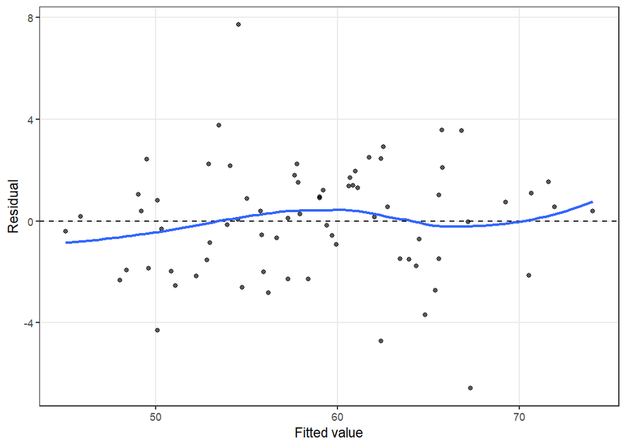

```r
if (exists("fit_linear")) {
  diag_linear <- mixed_diagnose(fit_linear)
  diag_linear
  mixed_plot(fit_linear, type = "residuals")
}
```

If strong curvature remains, the scientific mean model is incomplete.

# 14 13. Quadratic nitrogen response

```r
if (requireNamespace("lme4", quietly = TRUE)) {
  fit_quad <- mixed_fit(
    yield ~ variety * poly(nitrogen, 2) +
      (1 | block) +
      (1 | block:variety),
    data = d
  )
}
```

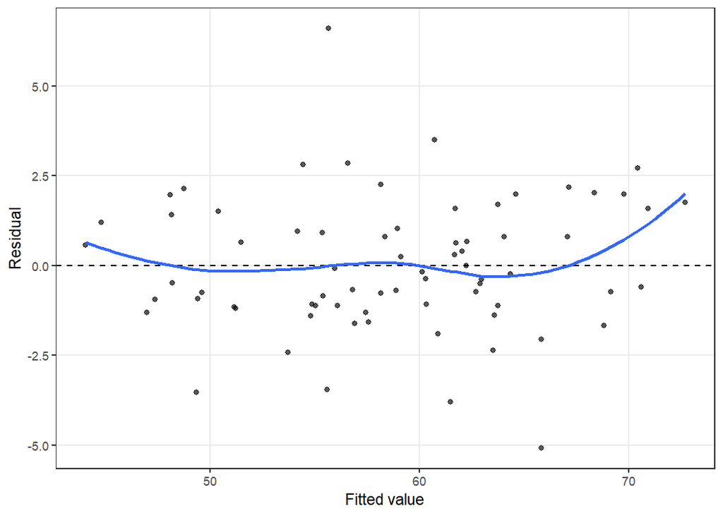

```r
if (exists("fit_quad")) {
  diag_quad <- mixed_diagnose(fit_quad)
  diag_quad
  mixed_plot(fit_quad, type = "residuals")
}
```

# 15 14. Compare mean structures carefully

Because the fixed-effect structures differ, likelihood comparison should use ML if an LRT is desired. For a descriptive comparison, use information criteria while still reviewing residual shape.

```r
if (requireNamespace("lme4", quietly = TRUE)) {
  linear_ml <- mixed_fit(
    yield ~ variety * nitrogen +
      (1 | block) + (1 | block:variety),
    data = d,
    REML = FALSE
  )

  quad_ml <- mixed_fit(
    yield ~ variety * poly(nitrogen, 2) +
      (1 | block) + (1 | block:variety),
    data = d,
    REML = FALSE
  )
}
```

```r
if (exists("linear_ml") && exists("quad_ml")) {
  mixed_compare(
    linear = linear_ml,
    quadratic = quad_ml,
    method = "information"
  )
}
```

```
#>       model engine                               fixed npar    logLik      AIC
#> 1    linear   lme4          yield ~ variety * nitrogen    9 -179.2943 376.5886
#> 2 quadratic   lme4 yield ~ variety * poly(nitrogen, 2)   12 -169.8581 363.7163
#>        BIC
#> 1 397.0786
#> 2 391.0363
```

# 16 15. Primary fixed-effect inference

If the quadratic model is retained for scientific and diagnostic reasons, use a small-sample method when appropriate.

```r
if (
  exists("fit_quad") &&
  requireNamespace("lmerTest", quietly = TRUE) &&
  requireNamespace("pbkrtest", quietly = TRUE)
) {
  mixed_anova(
    fit_quad,
    ddf = "Kenward-Roger"
  )
}
```

```
#>                                Sum Sq     Mean Sq NumDF DenDF     F value
#> variety                    243.248794  121.624397     2    10  25.3149827
#> poly(nitrogen, 2)         2092.720882 1046.360441     2    48 217.7901568
#> variety:poly(nitrogen, 2)    5.349875    1.337469     4    48   0.2783816
#>                                 Pr(>F)
#> variety                   1.220572e-04
#> poly(nitrogen, 2)         8.366484e-25
#> variety:poly(nitrogen, 2) 8.905320e-01
```

# 17 16. Variety estimated marginal means

```r
if (
  exists("fit_quad") &&
  requireNamespace("emmeans", quietly = TRUE)
) {
  variety_emm <- mixed_emmeans(
    fit_quad,
    specs = ~ variety
  )
  variety_emm
}
```

```
#>  variety emmean   SE   df lower.CL upper.CL
#>  V1        59.4 1.47 10.9     56.2     62.6
#>  V2        64.7 1.47 10.9     61.4     67.9
#>  V3        56.3 1.47 10.9     53.1     59.5
#>
#> Degrees-of-freedom method: kenward-roger
#> Confidence level used: 0.95
```

When a strong interaction is present, averaged variety EMMs require cautious interpretation.

# 18 17. Planned variety contrasts

```r
if (
  exists("fit_quad") &&
  requireNamespace("emmeans", quietly = TRUE)
) {
  mixed_contrasts(
    fit_quad,
    specs = ~ variety,
    method = "pairwise",
    adjust = "tukey"
  )
}
```

```
#>  contrast estimate   SE   df t.ratio p.value
#>  V1 - V2     -5.25 1.37 21.4  -3.832  0.0026
#>  V1 - V3      3.12 1.37 21.4   2.280  0.0806
#>  V2 - V3      8.37 1.37 21.4   6.111 <0.0001
#>
#> Degrees-of-freedom method: kenward-roger
#> P value adjustment: tukey method for comparing a family of 3 estimates
```

# 19 18. Quantitative nitrogen model helper

Fit the dedicated quadratic quantitative model.

```r
if (requireNamespace("lme4", quietly = TRUE)) {
  qfit <- mixed_quantitative(
    d,
    response = "yield",
    quantitative = "nitrogen",
    qualitative = "variety",
    group = "block",
    degree = 2,
    basis = "polynomial"
  )
}
```

This helper is convenient for trend/curve teaching. For the final split-plot analysis, always verify that the random structure fully represents the randomization required by the study.

# 20 19. Nitrogen trends

For the linear primary model, marginal slopes are straightforward.

```r
if (
  exists("fit_linear") &&
  requireNamespace("emmeans", quietly = TRUE)
) {
  slopes <- mixed_trend(
    fit_linear,
    specs = ~ variety,
    var = "nitrogen"
  )
  slopes
}
```

```
#>  variety nitrogen.trend      SE df lower.CL upper.CL
#>  V1              0.0982 0.00925 51   0.0796    0.117
#>  V2              0.0955 0.00925 51   0.0770    0.114
#>  V3              0.0890 0.00925 51   0.0704    0.108
#>
#> Degrees-of-freedom method: kenward-roger
#> Confidence level used: 0.95
```

# 21 20. Response curves

```r
if (
  exists("fit_quad") &&
  requireNamespace("emmeans", quietly = TRUE)
) {
  curve_data <- mixed_curve(
    fit_quad,
    variable = "nitrogen",
    values = seq(0, 150, by = 5),
    by = "variety"
  )

  head(curve_data)
}
```

```
#>  nitrogen variety   emmean       SE    df lower.CL upper.CL
#>         0 V1      49.47300 1.550292 13.40 46.13403 52.81197
#>         5 V1      50.29608 1.502562 11.91 47.01953 53.57264
#>        10 V1      51.09626 1.467070 10.86 47.86233 54.33020
#>        15 V1      51.87354 1.442473 10.17 48.66691 55.08017
#>        20 V1      52.62791 1.427231  9.76 49.43716 55.81866
#>        25 V1      53.35937 1.419700  9.56 50.17615 56.54259
#>
#> Degrees-of-freedom method: kenward-roger
#> Confidence level used: 0.95
```

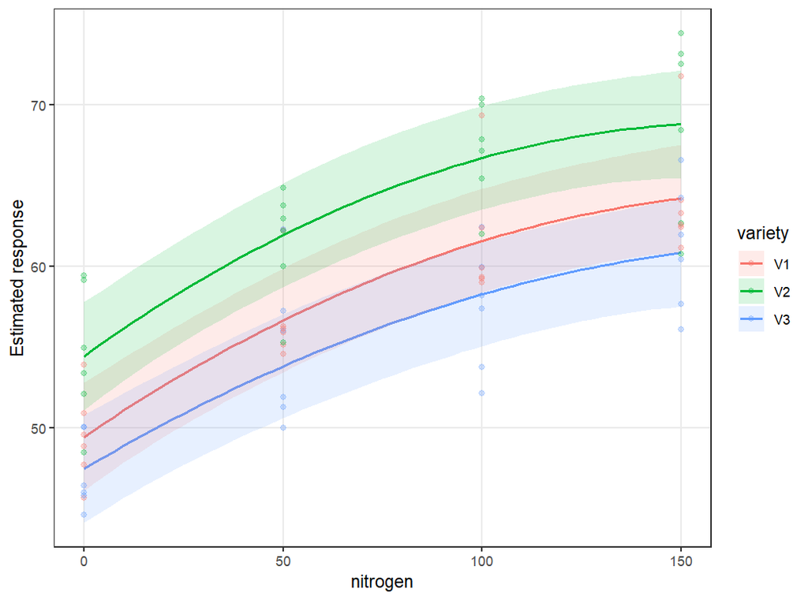

```r
if (
  exists("fit_quad") &&
  requireNamespace("emmeans", quietly = TRUE)
) {
  mixed_plot(
    fit_quad,
    type = "curve",
    x = "nitrogen",
    by = "variety",
    values = seq(0, 150, by = 2.5),
    show_data = TRUE
  )
}
```

**Primary biological interpretation:** describe the dose-response shape, treatment separation over the dose range, and uncertainty. Do not reduce the result to the significance of one polynomial coefficient.

# 22 21. Model-based optimum

```r
if (
  exists("fit_quad") &&
  requireNamespace("emmeans", quietly = TRUE)
) {
  opt <- mixed_optimum(
    fit_quad,
    variable = "nitrogen",
    range = c(0, 150),
    by = "variety",
    objective = "max",
    n = 501
  )

  opt
}
```

```
#>  nitrogen variety emmean   SE   df lower.CL upper.CL
#>       150 V1        64.2 1.55 13.4     60.9     67.5
#>       150 V2        68.8 1.55 13.4     65.4     72.1
#>       150 V3        60.9 1.55 13.4     57.5     64.2
#>
#> Degrees-of-freedom method: kenward-roger
#> Confidence level used: 0.95
```

The optimum is conditional on the fitted curve and the declared search range. It is not automatically an economic optimum.

# 23 22. Robust sensitivity analysis

Create the robust counterpart only if the Gaussian LMM is the relevant primary model and `robustlmm` is available.

```r
if (
  exists("fit_linear") &&
  requireNamespace("robustlmm", quietly = TRUE)
) {
  robust_fit <- mixed_robust(
    yield ~ variety * nitrogen +
      (1 | block) +
      (1 | block:variety),
    data = d
  )

  mixed_compare_robust(
    fit_linear,
    robust_fit
  )
}
```

```
#>                 term estimate.classical estimate.robust         shift
#> 1        (Intercept)       50.618246643    50.525475059 -0.0927715843
#> 2           nitrogen        0.098192542     0.098849640  0.0006570983
#> 3          varietyV2        5.190415282     5.063155397 -0.1272598848
#> 4 varietyV2:nitrogen       -0.002673057     0.001317265  0.0039903219
#> 5          varietyV3       -2.177138859    -2.634440385 -0.4573015257
#> 6 varietyV3:nitrogen       -0.009185585    -0.005594849  0.0035907360
#>   relative_shift
#> 1   -0.001832770
#> 2    0.006691937
#> 3   -0.024518247
#> 4    1.492793616
#> 5   -0.210047018
#> 6    0.390909869
```

A material shift should lead to observation/cluster review, not automatic exclusion.

# 24 23. Contamination screen

```r
if (exists("fit_linear")) {
  mixed_contamination(
    fit_linear,
    cluster = "whole_plot",
    threshold = 2.5
  )
}
```

```
#>    cluster flag abs_robust_z
#> 1    B1.V1    1   3.28517580
#> 2    B2.V1    0   1.08382264
#> 3    B3.V1    0   0.89148380
#> 4    B4.V1    0   0.64323244
#> 5    B5.V1    0   0.38548378
#> 6    B6.V1    0   0.16757801
#> 7    B1.V2    0   1.60452167
#> 8    B2.V2    0   0.98775833
#> 9    B3.V2    0   0.82523692
#> 10   B4.V2    0   0.58616125
#> 11   B5.V2    0   0.31865061
#> 12   B6.V2    0   0.11583150
#> 13   B1.V3    0   1.24089034
#> 14   B2.V3    0   0.95061931
#> 15   B3.V3    0   0.72167342
#> 16   B4.V3    0   0.44724294
#> 17   B5.V3    0   0.23806422
#> 18   B6.V3    0   0.06372963
```

# 25 24. Bootstrap fixed-effect uncertainty

Use a light vignette-scale bootstrap.

```r
if (exists("fit_linear")) {
  boot_demo <- mixed_boot_fixed(
    fit_linear,
    B = 49,
    seed = 260818
  )
}
```

Production analysis:

```r
boot_full <- mixed_boot_fixed(
  fit_linear,
  B = 4999,
  seed = 260818
)
```

# 26 25. Bootstrap variance components

```r
if (exists("fit_linear")) {
  boot_var_demo <- mixed_boot_variance(
    fit_linear,
    B = 49,
    seed = 260818
  )
}
```

Variance-component uncertainty can be asymmetric and is often scientifically important in hierarchical experiments.

# 27 26. Is GAMLSS needed?

Do **not** fit GAMLSS automatically. First ask whether residual scale or shape remains systematically related to treatment or dose after the core mean and covariance structure is adequate.

A sensitivity template:

```r
if (requireNamespace("gamlss", quietly = TRUE)) {
  g_loc <- mixed_gamlss(
    yield ~ variety * nitrogen,
    d,
    family = "NO",
    random = "block"
  )

  g_scale <- mixed_gamlss(
    yield ~ variety * nitrogen,
    d,
    family = "NO",
    sigma.formula = ~ variety,
    random = "block"
  )

  mixed_gamlss_select(
    constant_scale = g_loc,
    variety_scale = g_scale
  )
}
```

```
#> GAMLSS-RS iteration 1: Global Deviance = 393.0852
#> GAMLSS-RS iteration 2: Global Deviance = 393.0852
#> GAMLSS-RS iteration 1: Global Deviance = 391.903
#> GAMLSS-RS iteration 2: Global Deviance = 391.903
#>                         model     GAIC k
#> constant_scale constant_scale 407.0852 2
#> variety_scale   variety_scale 409.9030 2
```

This is a distributional sensitivity model, not a replacement for the split-plot randomization analysis unless the full hierarchy is represented appropriately.

# 28 27. Is a Bayesian model needed?

A Bayesian counterpart is justified when priors, posterior prediction, direct probability statements, or complex hierarchical uncertainty are central to the scientific aim.

```r
priors <- c(
  brms::prior(normal(0, 20), class = "Intercept"),
  brms::prior(normal(0, 5), class = "b"),
  brms::prior(exponential(1), class = "sd"),
  brms::prior(exponential(1), class = "sigma")
)

bayes_fit <- mixed_bayes(
  yield ~ variety * nitrogen +
    (1 | block) +
    (1 | block:variety),
  data = d,
  prior = priors,
  chains = 4,
  iter = 4000,
  seed = 260818
)

mixed_pp_check(bayes_fit)
```

The priors are placeholders for scale-aware refinement, not universal recommendations.

# 29 28. Fixed-effect table

```r
if (exists("fit_linear")) {
  mixed_table(
    fit_linear,
    component = "fixed",
    format = "markdown",
    digits = 3,
    caption = "Fixed-effect estimates for the design-correct LMM"
  )
}
```

Fixed-effect estimates for the design-correct LMM

| term | estimate | std.error |
| --- | --- | --- |
| (Intercept) | 50.618 | 1.524 |
| varietyV2 | 5.190 | 1.487 |
| varietyV3 | -2.177 | 1.487 |
| nitrogen | 0.098 | 0.009 |
| varietyV2:nitrogen | -0.003 | 0.013 |
| varietyV3:nitrogen | -0.009 | 0.013 |

# 30 29. Random-effect table

```r
if (exists("fit_linear")) {
  mixed_table(
    fit_linear,
    component = "random",
    format = "markdown",
    digits = 3,
    caption = "Random-effect variance components"
  )
}
```

Random-effect variance components

| grp | var1 | var2 | vcov | sdcor |
| --- | --- | --- | --- | --- |
| block:variety | (Intercept) | NA | 2.143 | 1.464 |
| block | (Intercept) | NA | 7.312 | 2.704 |
| Residual | NA | NA | 6.413 | 2.532 |

# 31 30. Diagnostic table

```r
if (exists("diag_linear")) {
  mixed_table(
    diag_linear,
    component = "diagnostics",
    format = "markdown",
    caption = "Diagnostic status"
  )
}
```

Diagnostic status

| engine | converged | singular | message |
| --- | --- | --- | --- |
| lme4 | TRUE | FALSE |  |

# 32 31. Publication figure set

A compact manuscript set can include:

**Figure A:** observed yield by nitrogen and variety.  
**Figure B:** model-based variety-specific response curves with uncertainty.  
**Figure C:** residual diagnostics.  
**Supplement:** random-effect or bootstrap uncertainty figure.

# 33 32. Export example

```r
mixed_plot(
  fit_quad,
  type = "curve",
  x = "nitrogen",
  by = "variety",
  values = seq(0, 150, by = 2.5),
  show_data = TRUE,
  file = "yield_nitrogen_curve.tiff",
  width = 7,
  height = 5,
  dpi = 600
)
```

# 34 33. Reproducible report

```r
if (exists("fit_linear")) {
  report_file <- tempfile(fileext = ".md")
  mixed_report(
    fit_linear,
    report_file,
    title = "Split-plot variety × nitrogen analysis"
  )

  readLines(report_file, n = 12)
}
```

```
#>  [1] "# Split-plot variety × nitrogen analysis"
#>  [2] ""
#>  [3] "Generated: 2026-08-18 23:55:16.647703"
#>  [4] "Engine: `lme4`"
#>  [5] ""
#>  [6] "## Model specification"
#>  [7] ""
#>  [8] "Call: `mixed_fit(formula = yield ~ variety * nitrogen + (1 | block) +      (1 | block:variety), data = d)`"
#>  [9] ""
#> [10] "## Required interpretation workflow"
#> [11] ""
#> [12] "1. Confirm experimental units and randomization."
```

# 35 34. Interpretation framework

A final narrative should follow this sequence.

## 35.1 Design

State that variety was randomized to whole plots and nitrogen to subplots within blocks.

## 35.2 Model

State the fixed variety-by-nitrogen mean structure and random block/whole-plot components.

## 35.3 Diagnostics

Report convergence, singularity, and residual adequacy.

## 35.4 Inferential result

Describe treatment-specific nitrogen response, uncertainty, and any important interaction.

## 35.5 Sensitivity

State whether robust or bootstrap analyses changed the substantive conclusion.

## 35.6 Limits

Do not extrapolate beyond tested nitrogen range or interpret a grid optimum as an economic recommendation without cost/price modeling.

# 36 35. Decision points for escalation

Escalate only if needed.

| Diagnostic/scientific problem | Extension |
| --- | --- |
| residual heteroscedasticity | `mixed_heterogeneity()` or distributional scale model |
| serial repeated measurements | `mixed_ar1()` / `mixed_car1()` |
| count response | `mixed_count()` |
| contamination sensitivity | `mixed_robust()` |
| difficult interval uncertainty | `mixed_boot()` |
| changing scale/shape | `mixed_gamlss()` |
| posterior probability/prior question | `mixed_bayes()` |
| nonlinear mechanistic response | `mixed_growth()` / `mixed_dose_response()` |
| field spatial trend | `mixed_spatial_field()` |
| multi-environment adaptation | `mixed_gxe()` |

# 37 36. What a complete analysis should not look like

Avoid:

1. fitting every available engine;
2. ranking all models by AIC;
3. reporting only the smallest p-value;
4. hiding convergence warnings;
5. deleting influential data without provenance review;
6. presenting EMM letters for quantitative dose as the main result;
7. showing only bars and standard errors;
8. interpreting a Bayesian credible interval as a frequentist CI;
9. treating spatial smoothing as a correction that is always beneficial.

For a manuscript archive, also store:

- source data checksum;
- analysis script;
- seed;
- package versions;
- exported figures/tables;
- model objects when storage permits;
- validation logs.

# 39 38. Capstone exercises

1. Repeat the workflow with nitrogen categorical and compare the scientific conclusions.
2. Create one missing subplot and explain how the mixed and classical routes differ.
3. Introduce a plausible influential observation and perform robust sensitivity analysis.
4. Bootstrap the variety-by-nitrogen slope and compare with the model-based SE.
5. Write a 250-word results section using the design-model-diagnostic-inference-sensitivity sequence.

# 40 39. Key take-home messages

- A complete mixed-model analysis begins with randomization, not software.
- Mean structure, covariance, distribution, and robustness are separate modeling questions.
- Quantitative treatments should preserve their scientific scale when possible.
- Advanced modules are escalation paths, not mandatory steps.
- Observed data, uncertainty, diagnostics, and reproducibility should remain visible in the final report.

# 41 40. Final next step

Use `20-api-example-catalog.Rmd` as the function-level reference after understanding the conceptual workflow developed across the tutorial series.